# DBP stats for 2018-11-16

## 1. Data processing and lens statistics

The applied filter selects the rows that are compliant with the following conditions :

- LTYPE includes PR
- ENGLOC==B > not enabled since ENGLOC is set to TRUE for some reason
- DLM TResult Measurement done flag is at TRUE

The total number of lenses included is : 350.

Some basic statistics :

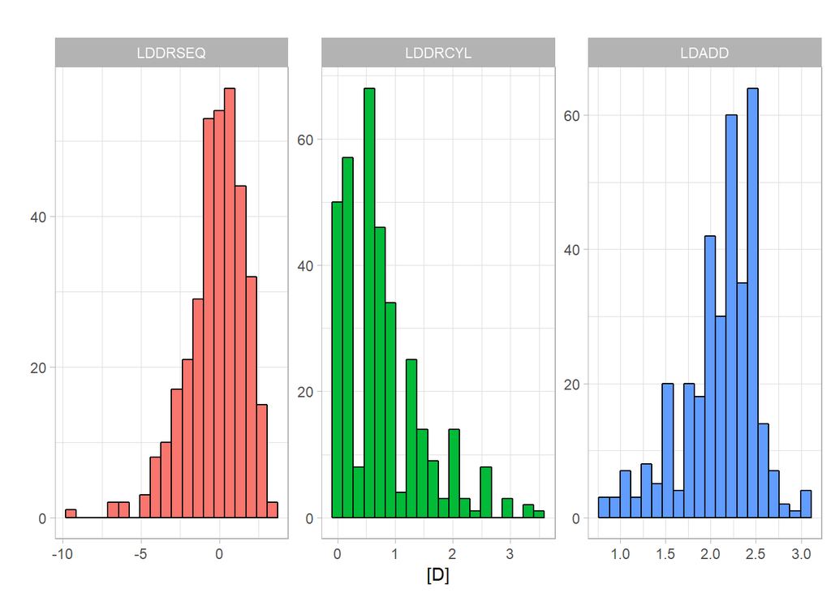

## 2. Preliminary engravings detection and position

### 2.1 PE Automatic detection rate

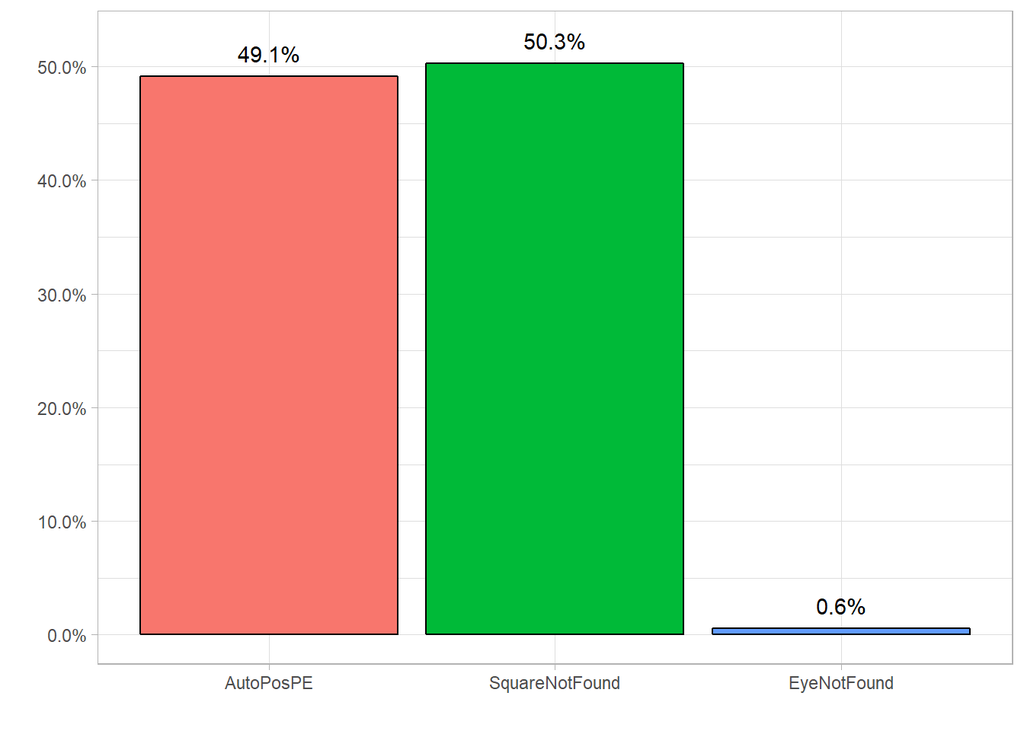

### 2.2 Preliminary engraving position vs. expected

Here the comparison of the position of the PRP based on the engravings at 34mm and the PRP based on the preliminary engravings.

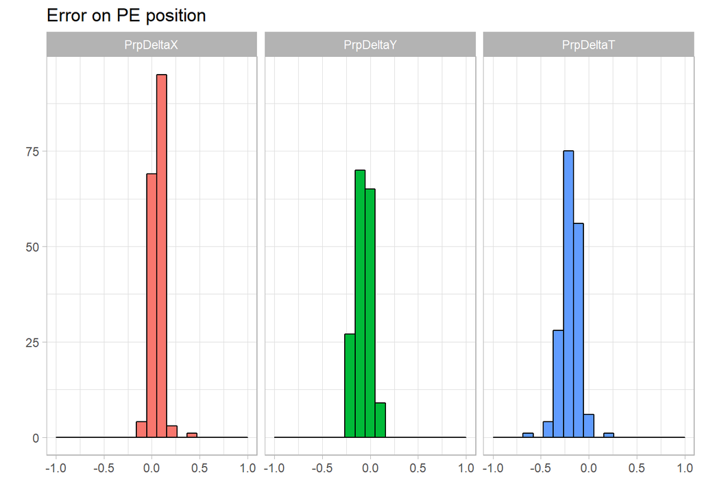

## 3. DBP success rate and output

### 3.1 DBP success rate

Here is the percentage of successful DBP processing.

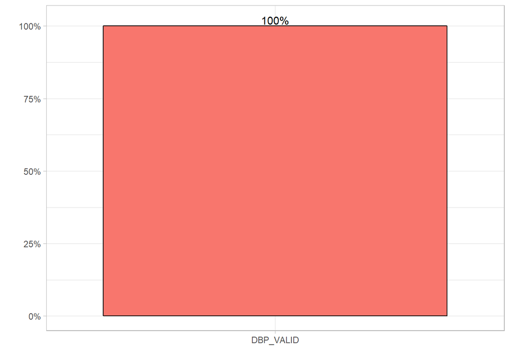

See the appendix for a list of the jobs with unsucessful DBP.

### 3.2 DBP values

Percentage of DBP values in interval [-2,2] for x and y and [-5,5] for $\theta$.

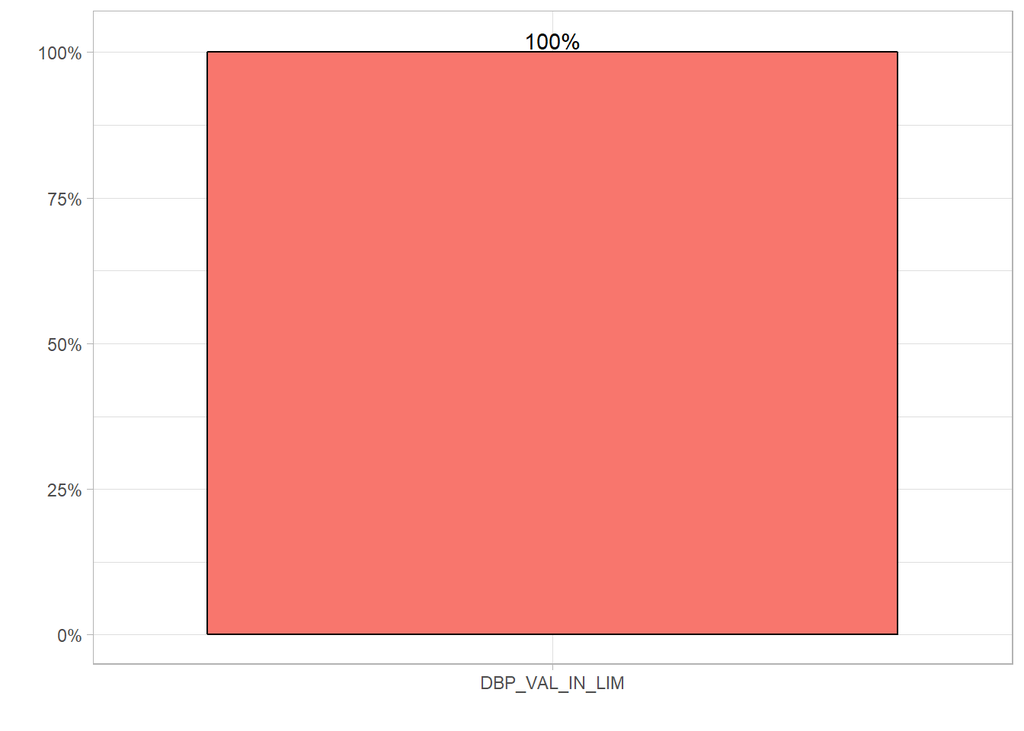

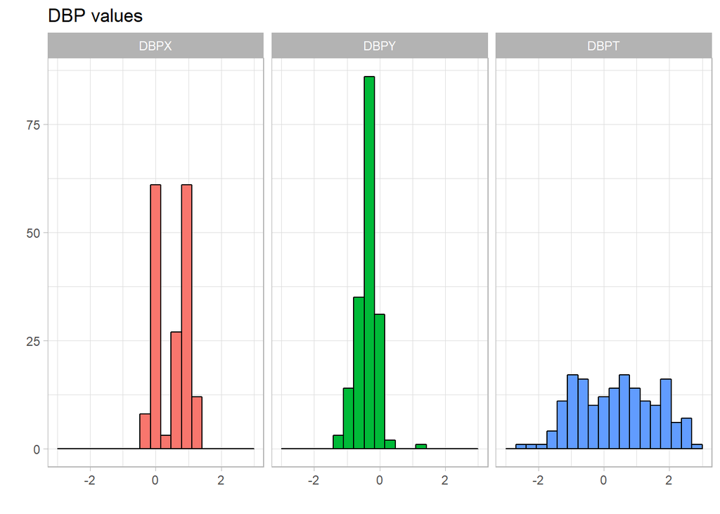

### 3.3 DBP FE and SE values

These are the two validity criteria for the DBP. DBPFE represents the average error and DBPSE the sensitivity against shifting.

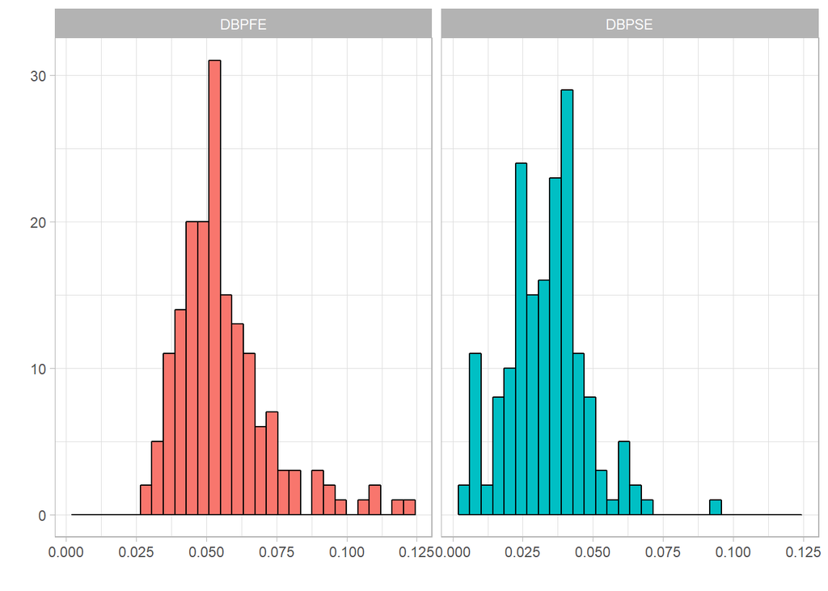

## 4. Errors statistics with DBP OFF and ON

### 4.1 Relative prism error with DBP OFF and ON

Here are the relative error on the prismatic powers. This errors are the difference between the measured values and the verifications value divided by the tolerance compliant with the ISO8980-2. The values with and without DBP are compared.

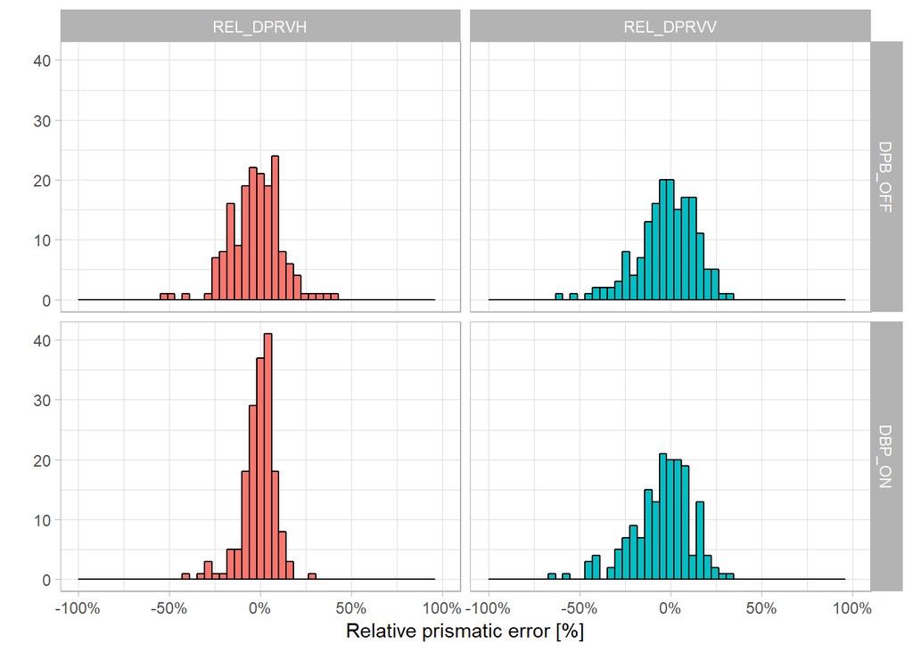

### 4.2 Vector cylinder power errors with DBP OFF and ON

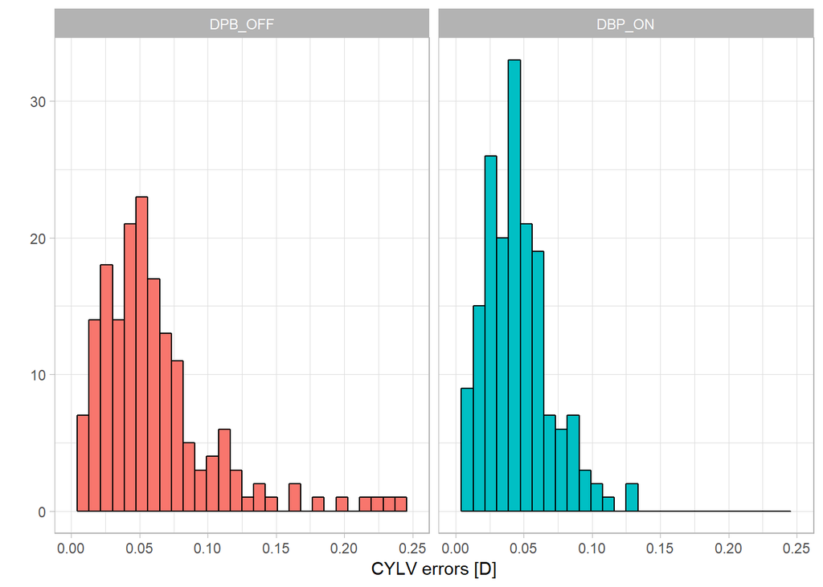

### 4.3 GMC statistics with DBP OFF and ON

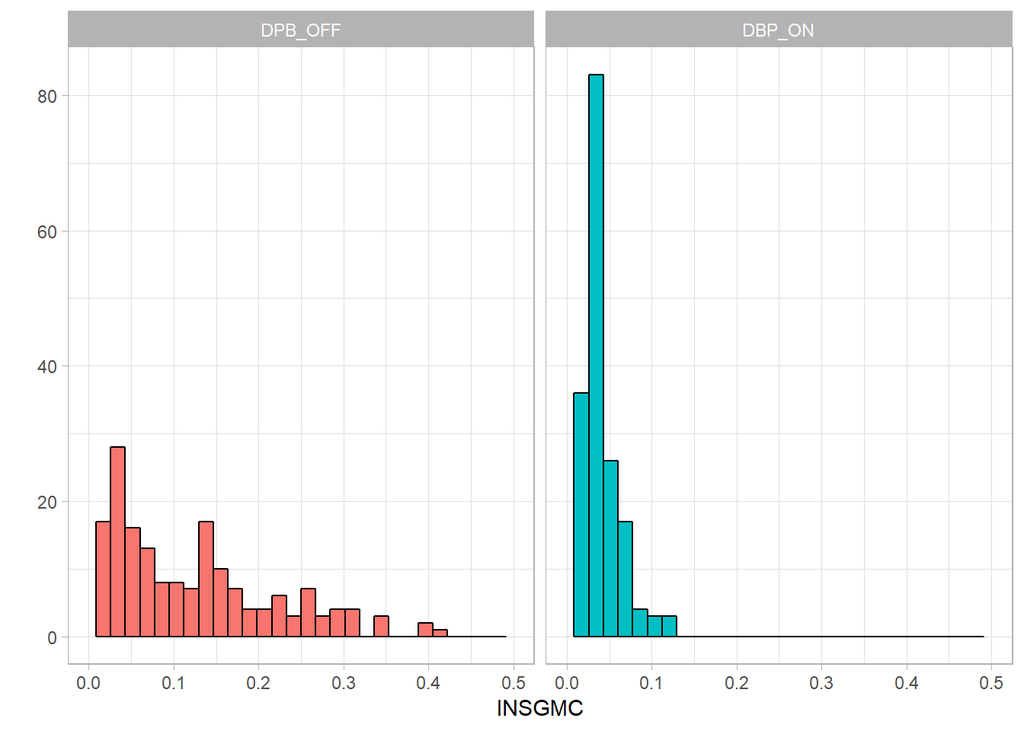

### 4.4 AV statistics with DBP OFF and ON

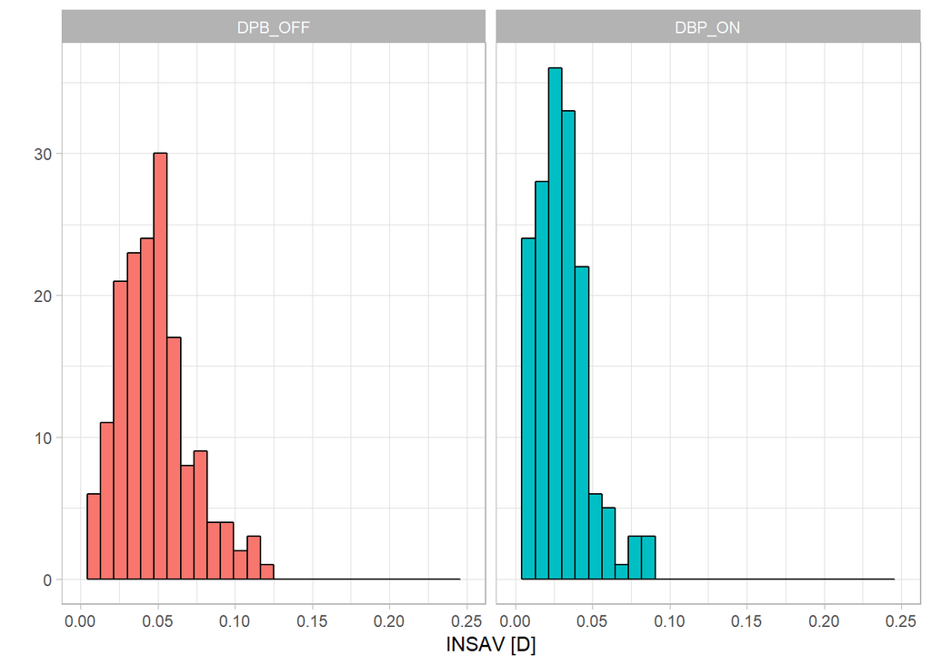

## Appendix

### Unsucessfull DBP jobs

JOB EYE DBPVALID —- —- ———